# Лабораторная работа №5

Конфигурация VLAN

Ко Антон Геннадьевич

antonkosakh@gmail.com

Российский университет дружбы народов

2026-09-04

# Информация

## Докладчик

- Ко Антон Геннадьевич
- студент
- Российский университет дружбы народов им. П. Лумумбы
- 1132221551@rudn.ru
- https://SenDerMen04.github.io/ru/

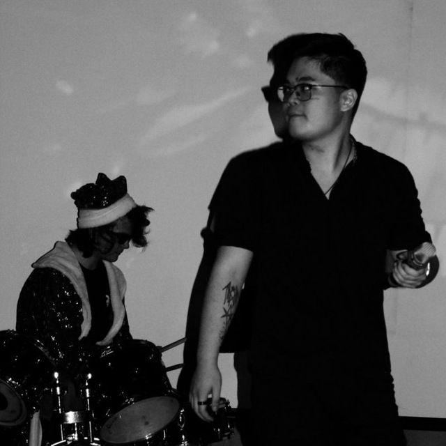

## Цель работы

Получить основные навыки по настройке VLAN на коммутаторах сети.

## Выполнение работы

Используя приведённую в лабораторной работе последовательность команд из примера по конфигурации Trunk-порта на интерфейсе g0/1 коммутатора `msk-donskaya-sw-1`, настроим Trunk-порты на соответствующих интерфейсах всех коммутаторов (рис. #fig:002 – #fig:006):

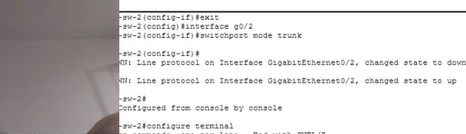

Настройка Trunk-портов на коммутаторе msk-donskaya-agko-sw-2

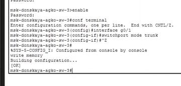

Настройка Trunk-портов на коммутаторе msk-donskaya-agko-sw-3

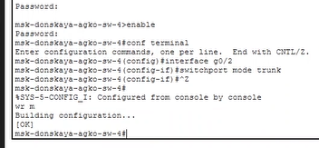

Настройка Trunk-портов на коммутаторе msk-donskaya-agko-sw-4

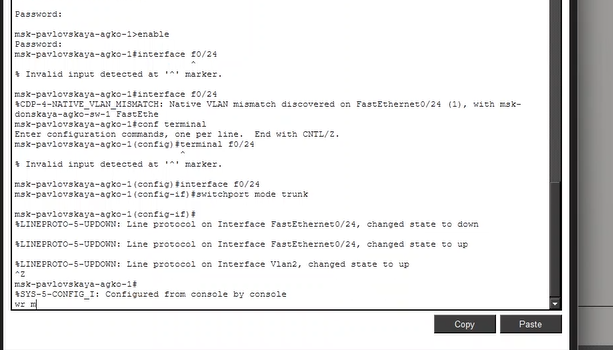

Настройка Trunk-портов на коммутаторе msk-pavlovskaya-agko-sw-1

Далее настроим коммутатор `msk-donskaya-agko-sw-1` как VTP-сервер и пропишем на нём номера и названия VLAN (рис. #fig:007):

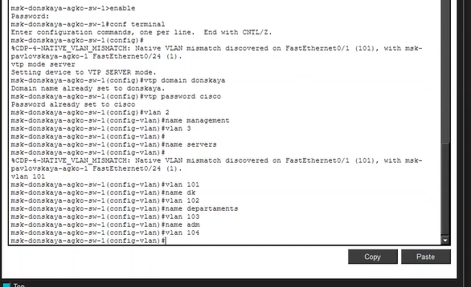

Настройка коммутатора msk-donskaya-agko-sw-1 как VTP-сервера, добавление номеров и названий VLAN

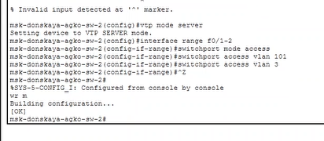

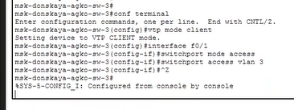

Настройка коммутатора msk-donskaya-agko-sw-3 как VTP-клиента и указание принадлежности к VLAN

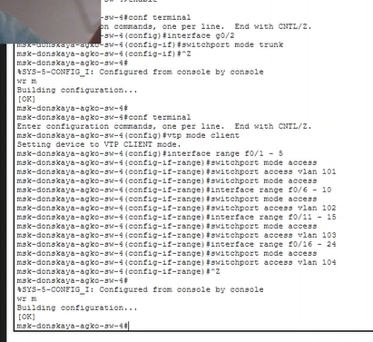

Настройка коммутатора msk-donskaya-agko-sw-4 как VTP-клиента и указание принадлежности к VLAN

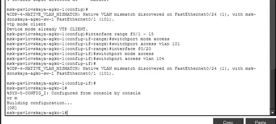

Настройка коммутатора msk-pavlovskaya-agko-sw-1 как VTP-клиента и указание принадлежности к VLAN

Затем требуется указать статические IP-адреса на оконечных устройствах (рис. #fig:012 – #fig:013):

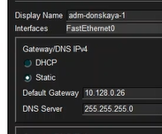

Пример указания статического IP-адреса на оконечном устройстве (Default Gateway)

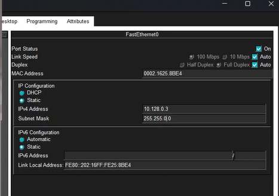

Пример указания статического IP-адреса на оконечном устройстве (IP Configuration)

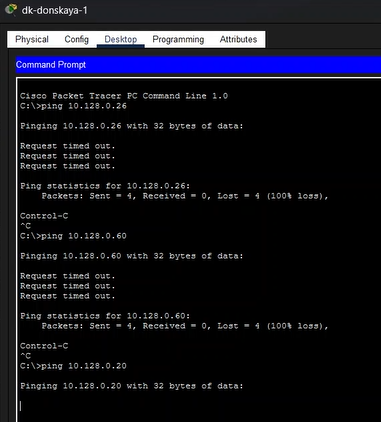

Проверка доступности устройств с помощью ping

## Вывод

В ходе выполнения лабораторной работы мы получили основные навыки по настройке VLAN на коммутаторах сети.